# Математическое моделирование

Лабораторная работа № 5

Джафар Идрисов

1132232876@rudn.ru

Российский университет дружбы народов

2026-04-13

# Вводная часть

## Цель работы

Изучить модель хищник-жертва и исследовать её поведение в базовом и расширенном вариантах.

## Задание

1. Построить график зависимости численности хищников от численности жертв.
2. Построить графики изменения численности хищников и жертв во времени.
3. Найти стационарное состояние системы.
4. Сравнить базовую и расширенную модели.
5. Выполнить параметрическое исследование.

# Теоретические сведения

## Модель хищник-жертва

В лабораторной работе рассматривается классическая модель Лотки–Вольтерры, описывающая взаимодействие двух популяций: хищников и жертв.

Пусть:

- $x(t)$ — численность хищников;
- $y(t)$ — численность жертв.

Тогда система уравнений имеет вид:

$$\begin{cases}
\frac{dx}{dt} = -ax(t) + by(t)x(t), \\
\frac{dy}{dt} = cy(t) - dy(t)x(t).
\end{cases}$$

## Интерпретация параметров

Здесь:

- $a$ — коэффициент смертности хищников;
- $b$ — коэффициент прироста хищников;
- $c$ — коэффициент прироста жертв;
- $d$ — коэффициент смертности жертв.

Изменение этих параметров влияет на характер динамики системы.

## Стационарное состояние

Стационарное состояние определяется из условий:

$$\frac{dx}{dt}=0, \qquad \frac{dy}{dt}=0.$$

Это состояние соответствует равновесию, при котором численности популяций не изменяются.

# Постановка задачи

## Исследуемая система

Для модели «хищник-жертва» задана система:

$$\begin{cases}
\frac{dx}{dt} = -0.25x(t) + 0.025y(t)x(t), \\
\frac{dy}{dt} = 0.45y(t) - 0.045y(t)x(t).
\end{cases}$$

## Начальные условия

Используются начальные условия:

$$x_0 = 8, \qquad y_0 = 11.$$

## Стационарное состояние системы

Следовательно, стационарное состояние системы:

$$(10, 10).$$

# Базовые эксперименты

## Базовая модель: временные зависимости

[figure not shown]

## Базовая модель: фазовый портрет

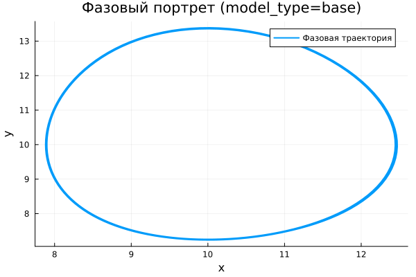

## Базовая модель: анализ

Для базовой модели наблюдаются устойчивые периодические колебания обеих переменных.

Основные особенности:

- численности жертв и хищников изменяются периодически;
- амплитуда колебаний остаётся практически постоянной;
- система не переходит к состоянию покоя;
- фазовая траектория замкнута.

Следовательно, базовая модель демонстрирует классический незатухающий колебательный режим.

## Расширенная модель: временные зависимости

[figure not shown]

## Расширенная модель: фазовый портрет

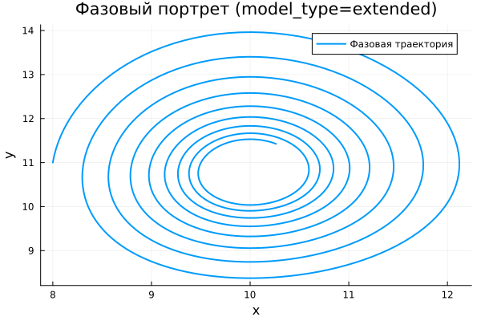

## Расширенная модель: анализ

В расширенной модели колебания сохраняются, но их амплитуда постепенно уменьшается.

Наблюдения:

- в начале колебания выражены сильно;
- затем амплитуда уменьшается;
- система стремится к устойчивому состоянию;
- фазовая траектория принимает вид закручивающейся спирали.

Следовательно, дополнительный нелинейный член стабилизирует динамику и приводит к затуханию колебаний.

# Параметрическое исследование

## Сканирование траекторий $x(t)$

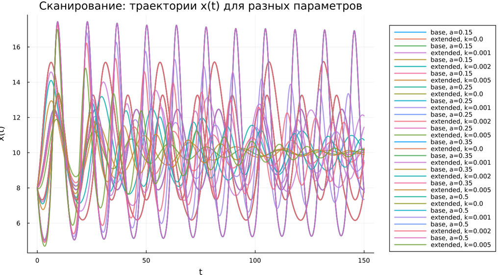

## Анализ траекторий $x(t)$

Было проведено исследование параметров двух моделей.

Результаты:

- в базовой модели изменение параметра $a$ влияет на амплитуду и частоту колебаний;
- режим остаётся колебательным на всём интервале;
- в расширенной модели параметр $k$ влияет на скорость затухания;
- при увеличении $k$ система быстрее выходит на стационарное состояние.

## Сканирование траекторий $y(t)$

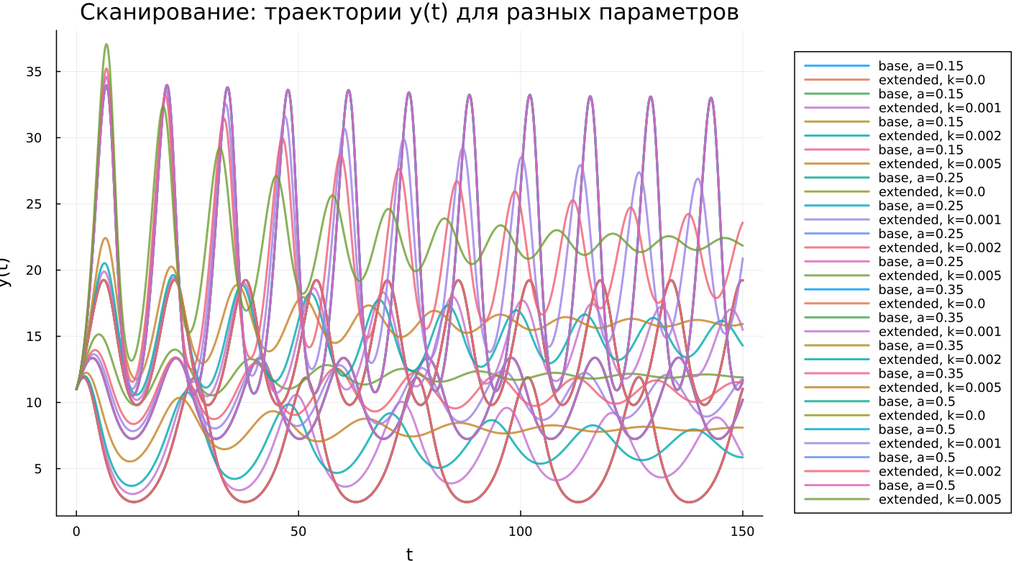

## Анализ траекторий $y(t)$

Для переменной $y(t)$ наблюдаются аналогичные закономерности:

- в базовой модели сохраняются регулярные периодические колебания;
- в расширенной модели амплитуда со временем уменьшается;
- увеличение нелинейного ограничения ускоряет стабилизацию;
- система стремится к устойчивому состоянию.

## Фазовые траектории

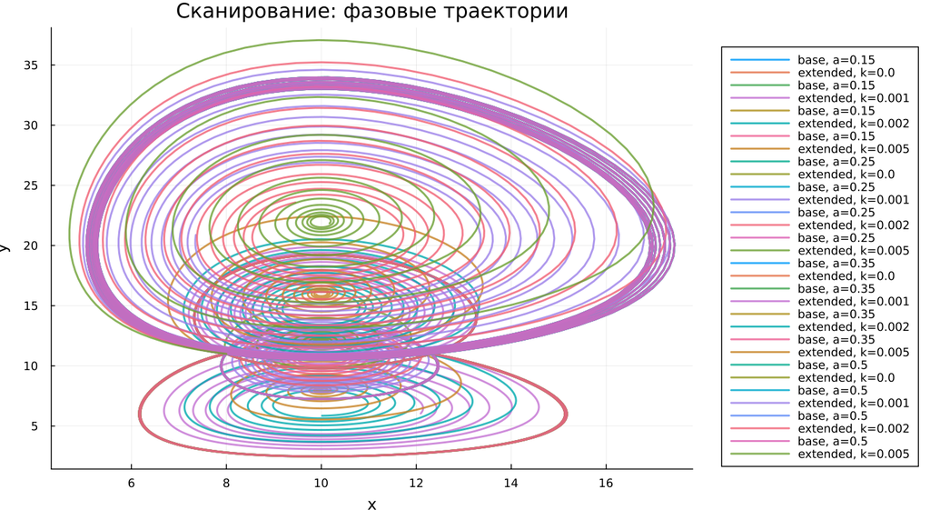

## Анализ фазовых траекторий

Сравнение фазовых портретов показывает качественное различие моделей:

- для базовой модели характерны замкнутые траектории;
- для расширенной модели траектории имеют спиральный характер;
- базовая система сохраняет автоколебания;
- расширенная система стремится к равновесию.

Фазовые портреты подтверждают фундаментальное различие динамики двух моделей.

# Анализ итоговой метрики

## Метрика norm_final

Рассматривалась величина:

$$\text{norm\_final} = \sqrt{x(t_{final})^2 + y(t_{final})^2}.$$

Она характеризует состояние системы в конце интервала моделирования.

## Зависимость norm_final от параметра

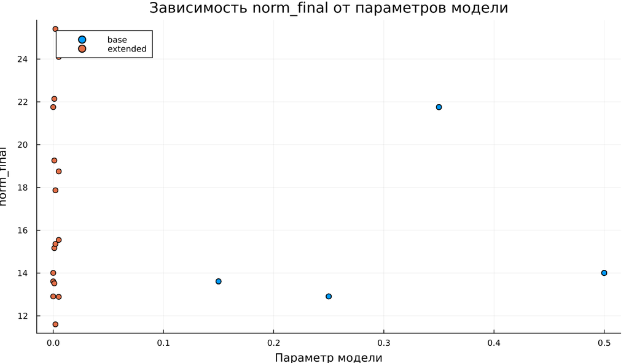

## Интерпретация результата

# Анализ вычислений

## Время вычислений

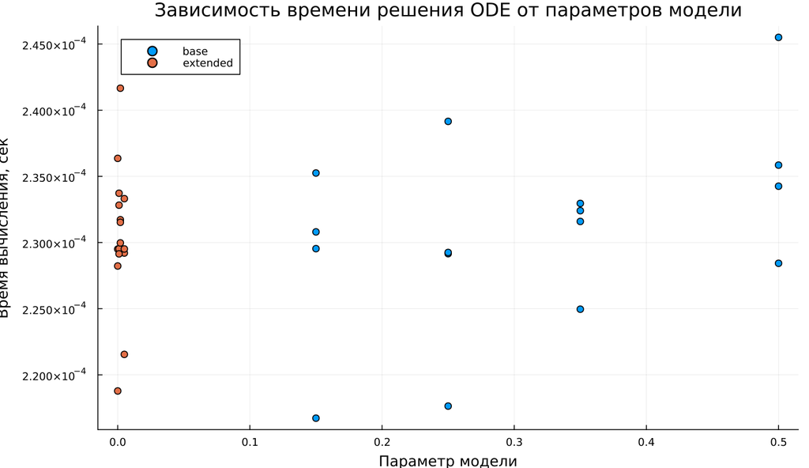

## Интерпретация времени вычислений

Бенчмаркинг показал:

- обе модели вычисляются быстро;
- время расчёта остаётся очень малым;
- изменение параметров не приводит к существенному росту вычислительных затрат;
- усложнение модели не ухудшает её численную разрешимость.

Следовательно, используемая схема интегрирования является эффективной.

# Итоги